[figure not shown]

# Ulam Spirals

I came across [Ulam spirals](https://en.wikipedia.org/wiki/Ulam_spiral) and [Sacks spirals](https://en.wikipedia.org/wiki/Ulam_spiral#Variants) on this [numberphile video](https://www.youtube.com/watch?v=iFuR97YcSLM). The Ulam spiral (or prime spiral or ulam cloth) is, according to [Wikipedia](https://en.wikipedia.org/wiki/Ulam_spiral),

> a method of visualizing the prime numbers that reveals the apparent tendency of certain quadratic polynomials to generate unusually large numbers of primes.

The story goes that

> it was discovered by the mathematician Stanislaw Ulam in 1963, while he was doodling during the presentation of a "long and very boring paper" at a scientific meeting.

A reveal of the Ulam spiral is *some* pattern to the prime number distribution relating to some "rich" (in primes) quadratics. Maybe it shouldn't be too surprising that despite the prime number distribution being *random* (without thinking too much about what that means) there are some patterns. After all some pattern examples of the prime distribution are quite straighforward e.g. primes after `2` must be odd, or primes must be of the form `6n+1` or `6n-1`. But the Ulam spiral was a surprise when discovered and according to the numberphile video is not very well understood.

This page shows a way to create visualisations of the Ulam spirals and the Sacks spirals (an Archimedean spiral variant of a Ulam spiral) using [Julia](http://julialang.org/).

#### Packages

We'll use the Primes Package to test whether a number is prime, the [Images package](https://github.com/timholy/Images.jl) and [Colors package](https://github.com/JuliaGraphics/Colors.jl) for plotting the Ulam spirals, and (further down) the [Gadfly package](http://gadflyjl.org/stable/) for plotting the Sacks spirals.

```julia
using Primes, Images, Colors
```

The **spiral(n)** function returns a spiral matrix of size $n \times n$ (spiralling out from the center). There are options to choose the starting number (defaults to `1`) and increments (defaults to `1`).

```julia
function spiral(n::Int; start::Int = 1, incr::Int = 1)

    # Create vector and empty matrix
    finish = start + incr * (n^2 - 1)
    nums = collect(start:incr:finish)
    S = zeros(Int, n, n)

    # Starting location
    row = ceil(Int, ((n + 1) / 2))
    col = floor(Int, ((n + 1) / 2))

    # Wrap numbers around matrix
    S[row, col] = splice!(nums, 1)
    for i = 1:n-col
        k = i-1
        length = 2i
        S[(row - i):(row + k), (col + i)] = reverse(splice!(nums, 1:length))
        if size(nums,1) == n-1
            S[(row - i), (col - k):(col + k)] = reverse(nums)
            break
        end
        S[(row - i), (col - i):(col + k)] = reverse(splice!(nums, 1:length))
        S[(row - k):(row + i), (col - i)] = splice!(nums, 1:length)
        S[(row + i), (col - k):(col + i)] = splice!(nums, 1:length)
    end

    # Return spiral matrix
    S
end;
```

A `10 x 10` spiral matrix looks like this:

```julia
spiral(10)
```

```
10×10 Array{Int64,2}:
 100  99  98  97  96  95  94  93  92  91
  65  64  63  62  61  60  59  58  57  90
  66  37  36  35  34  33  32  31  56  89
  67  38  17  16  15  14  13  30  55  88
  68  39  18   5   4   3  12  29  54  87
  69  40  19   6   1   2  11  28  53  86
  70  41  20   7   8   9  10  27  52  85
  71  42  21  22  23  24  25  26  51  84
  72  43  44  45  46  47  48  49  50  83
  73  74  75  76  77  78  79  80  81  82
```

The **ulam(n)** function first creates a spiral matrix and then plots the Ulam spiral.

```julia
function ulam(n::Int; col_prime = colorant"navy", col_background = colorant"white", start = 1, incr = 1)
    S = spiral(n, start = start, incr = incr)
    canvas = [isprime(S[i,j]) ? col_prime : col_background for i = 1:size(S, 1), j = 1:size(S, 2)]
    display("image/png", imresize(canvas, (500, 500)))
end;
```

[figure not shown]

```julia
ulam(200)
```

You can start at any number and still find that primes appear along the diagonals. The image below is for a Ulam sprial starting at `41`. Notice the very long low-left to top-right diagonal. These points all lie on $x^2-x+41$ which produces `41` primes in a row for $x=0,1,2,\dots,40$.

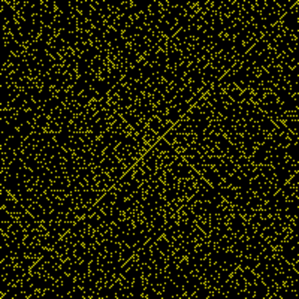

```julia
ulam(200, start = 41, col_prime = colorant"yellow", col_background = colorant"black")
```

Playing around a bit, let's see what happens when starting at `3` and incrementing by `2` i.e. only odd numbers. I can't see any obviously interesting pattern emerging.

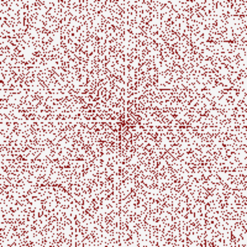

```julia
ulam(200, start=3, incr=2, col_prime = colorant"maroon", col_background = colorant"whitesmoke")
```

Another thing we can do is highlight some of the quadratic polynomials that are quite rich in primes e.g. Eulers prime generating polynomial $x^2 - x + 41$ or the highly rich $4x^2 - 2x + 41$.

```julia
function ulam(n::Int, f::Function;
              col_prime = colorant"red2", col_func = colorant"navy", col_background = colorant"white", start = 1, incr = 1)
    S = spiral(n)
    p = [f(x) for x in -n:n]
    canvas = [isprime(S[i,j]) ? any(p .== S[i,j]) ? col_func : col_prime : col_background for i = 1:size(S,1), j = 1:size(S,2)]
    display("image/png", imresize(canvas, (500, 500)))
end;
```

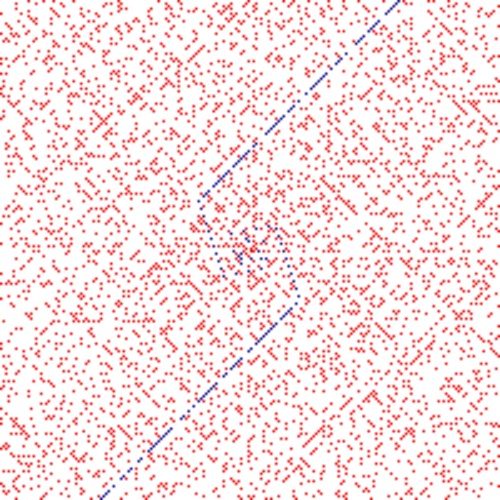

```julia
ulam(200, x -> 4x^2 - 2x + 41)
```

### Sacks spiral

The Sacks spiral is a variant of the Ulam spiral where, instead of plotting numbers on a rectangular spiral, they are plotted on an [Archimedean spiral](https://en.wikipedia.org/wiki/Archimedean_spiral).

An Archimedean spiral is the locus of points leading away from a central point with fixed speed and fixed angular velocity i.e. as you turn the angle $(\theta)$ round and round, the radius $(r)$ (or distance from the origin) grows at a constant rate. The relationship between radius and angle is

$$r(\theta) = a + b \, \theta$$

with $a$ & $b$ $\in \mathbb{R}$. Parameter $a$ turns the spiral and parameter $b$ controls the distance between the spiral arms.

To create a Sacks spiral we need to first place all the whole numbers $(i = 0, \, 1, \, 2, \, 3, \, \dots)$ along an Archimedean spiral such that all square numbers $(i = 0, \, 1, \, 4, \, 9, \, \dots)$ are on the positive x axis. Then, with all the numbers in place, we plot only the prime number positions.

For plotting it will be easier to use a plotting package instead of an image package as now we are plotting point locations as opposed to colouring rectangular canvas pixels. The Gadfly package is easy to use and produces beautiful quality plots.

```julia
using Gadfly
```

Before plotting we need to work out the Sacks version of the Archimedean spiral and tackle the polar coordinates system. Hopefully this is a quick digression.

If the square numbers are all placed on the positive x axis then

$$\theta(i^2)=2\pi i \quad \text{or} \quad \theta(i)=2\pi \sqrt{i}$$

i.e. $i^2$ is placed (on the x axis) after $i$ rotations. Substituting into the equation for $r$ gives

$$r(i) = a + b \, 2\pi\sqrt{i}$$

.

To calculate the value of $a$ note that $$r(0) = 0 \implies a + b \, 2\pi\sqrt{0} = 0 \implies a=0$$.

Since $b$ just controls the distance between spiral arms (effectively the "zoom") we can set it to any value and it's convenient to let $b=\frac{1}{2\pi}$. We then have:

$$r(i) = \sqrt{i} \quad \text{and} \quad \theta(i) = 2\pi \, r(i)$$

For plotting, we can calculate the Cartesian coordinates from the polar coordinates using:

$$x = r \cos(\theta) \quad \text{and} \quad y = r \sin(\theta)$$

The chart below illustrates this method of placing the whole numbers on the Archemedean spiral. The function **archimedean_pts($n$)** creates the location of the whole numbers - will plot the points. And **archimedean_line($n$)** creates the location of a range of real numbers - will plot the path. If you count the dots (starting with $0$) from the origin you'll see that the square numbers $(0, \, 1, \, 4, \, 9, \, \dots)$ are all on the positive x axis.

```julia
function archimedean_pts(n)
    r(i) = sqrt(i)
    θ(i) = 2π * r(i)
    range = 0:n
    x = [r(i) * cos(θ(i)) for i in range]
    y = [r(i) * sin(θ(i)) for i in range]
    return x, y
end;
```

```julia
function archimedean_line(n)
    r(i) = sqrt(i)
    θ(i) = 2π * r(i)
    range = linspace(0, n, 10000)
    x = [r(i) * cos(θ(i)) for i in range]
    y = [r(i) * sin(θ(i)) for i in range]
    return x, y
end;
```

```julia
x1, y1 = archimedean_pts(100)
x2, y2 = archimedean_line(100)
set_default_plot_size(12cm, 12cm)
plot(layer(x = x1, y = y1, Geom.point, Theme(default_color = colorant"blue4")),
     layer(x = x2, y = y2, Geom.path, Theme(default_color = colorant"grey")))
```

[figure not shown]

Now we're ready to create the Sacks spiral.

The function **sacks(n)** is similar to **archimedean(n)** but only produces the prime number points. And the function **plot_sacks(n; ...)** plots the spiral.

```julia
function sacks(n)
    x = Array{Float64}(0)
    y = Array{Float64}(0)
    for i in 1:n
        if isprime(i)
            r = sqrt(i)
            θ = 2π * r
            push!(x, r * cos(θ))
            push!(y, r * sin(θ))
        end
    end
    return x, y
end;
```

```julia
function plot_sacks(n; point_size = 0.05cm, highlight_width = 0.005cm, default_color = colorant"blue4")
    xs, ys = sacks(n)
    theme = Theme(point_size = point_size, highlight_width = highlight_width, default_color = default_color)
    guide = Guide.xticks(ticks = nothing), Guide.yticks(ticks = nothing), Guide.xlabel(nothing), Guide.ylabel(nothing)
    return plot(x = xs, y = ys, guide..., theme)
end;
```

Numbers up to `10,000`:

```julia
set_default_plot_size(15cm, 15cm)
plot_sacks(10000)
```

[figure not shown]

Numbers up to `40,000`:

```julia
set_default_plot_size(25cm, 25cm)
plot_sacks(40000, point_size = 0.04cm, highlight_width = 0.005cm, default_color = colorant"darkred")
```

[figure not shown]